# pyMódulo 10

Curso IE0217 Estructuras abstractas y algoritmos para ingeniería - UCR

Profesor Freddy Rojas Ch.

2/02/2021

# Lenguaje Python 3 Módulo 10

Se explorarn en el módulo 10 aspectos avanzados de manejo de *data_frames* como preámbulo al análsiis de datos mediante métodos de exploración.

## Operaciones usando *numpy* en Python.

### Estadísticas y uso de *axis*.

En este ejemplo se realizarán operaciones estadísticas. Adicionalmente el parámetro *axis* dentro de las operaciones con *data frames* se refiere al sentido de recorrido de la operación. *axis=0* implica un recorrido por columnas, que es el recorrido por *omision*, ya que se asume que las columnas representa variables y los nombres de las filas son las etiquetas de las observaciones.

```python
import numpy as np

M = np.random.random((3, 4))
print(M)
```

```
## [[0.35645087 0.17193732 0.23411335 0.64322597]
##  [0.61112092 0.64437774 0.92296932 0.49431833]
##  [0.03838906 0.28769745 0.15880506 0.94694585]]
```

```python
M.sum() # Es el llamado a un método de nunpy
```

```
## 5.510351245003717
```

```python
M.min(axis=0) # Por columna
```

```
## array([0.03838906, 0.17193732, 0.15880506, 0.49431833])
```

```python
M.min(axis=1) # Por fila
```

```
## array([0.17193732, 0.49431833, 0.03838906])
```

```python
datos = np.array([189, 170, 189, 163, 183, 171, 185, 168, 173, 183, 173, 173,
                  175, 178, 183, 193, 178, 173, 174, 183, 183, 168, 170, 178,
                  182, 180, 183, 178, 182, 188, 175, 179, 183, 193, 182, 183,
                  177, 185, 188, 188, 182, 185])

print(datos)
```

```
## [189 170 189 163 183 171 185 168 173 183 173 173 175 178 183 193 178 173
##  174 183 183 168 170 178 182 180 183 178 182 188 175 179 183 193 182 183
##  177 185 188 188 182 185]
```

```python
print("Promedio:            ", datos.mean())
```

```
## Promedio:             179.73809523809524
```

```python
print("Desviación Estándar: ", datos.std())
```

```
## Desviación Estándar:  6.931843442745892
```

```python
print("Mínimo:              ", datos.min())
```

```
## Mínimo:               163
```

```python
print("Máximo:              ", datos.max())
```

```
## Máximo:               193
```

```python
print("Percentile 25:       ", np.percentile(datos, 25))
```

```
## Percentile 25:        174.25
```

```python
print("Mediana :            ", np.median(datos))
```

```
## Mediana :             182.0
```

```python
print("Percentile 75:       ", np.percentile(datos, 75))
```

```
## Percentile 75:        183.0
```

#### Operaciones sobre componentes de listas con *numpy*

```python
# Se genera una secuencia de 10 elementos de 0 a 9
x = np.arange(10)
print(x)

# Se construye un arreglo de valores predefinidos que se usan como index
```

```
## [0 1 2 3 4 5 6 7 8 9]
```

```python
i = np.array([2, 1, 8, 4])
print(i)

#modifica las posiciones de x[] en los valores indexados por i
```

```
## [2 1 8 4]
```

```python
x[i] = 99
print(x)

# Ordenando vectores con numpy
```

```
## [ 0 99 99  3 99  5  6  7 99  9]
```

```python
x = np.array([9, 1, -4, 23, 5])
np.sort(x)

# Usando el método 'sort'
```

```
## array([-4,  1,  5,  9, 23])
```

```python
x.sort()
print(x)

#Se construye x como un arreglo dado
```

```
## [-4  1  5  9 23]
```

```python
x = np.array([9, 1, -4, 23, 5])

#Se genera un vector de índices que corresponde a las posiciones ordenadas.
i = np.argsort(x)
print(i)
```

```
## [2 1 4 0 3]
```

```python
print(x[i])
```

```
## [-4  1  5  9 23]
```

Ahora ejemplos con números aleatorios y ordenamientos por fila o columna

```python
# Se construye un generador de números aleatorios.
rand = np.random.RandomState(42)

# Se genera una matriz de 5x7 con números aleatorios enteros de 0 a 29
X = rand.randint(0, 30, (5, 7))
print(X)

# Usando los ejes por vertical (axis=0) o horizongal (axis=1)
```

```
## [[ 6 19 28 14 10  7 28]
##  [20  6 25 18 22 10 10]
##  [23 20  3  7 23  2 21]
##  [20  1 23 11 29  5  1]
##  [27 20  0 11 25 21 28]]
```

```python
print(np.sort(X, axis=0)) # Ordena por columna
```

```
## [[ 6  1  0  7 10  2  1]
##  [20  6  3 11 22  5 10]
##  [20 19 23 11 23  7 21]
##  [23 20 25 14 25 10 28]
##  [27 20 28 18 29 21 28]]
```

```python
print(np.sort(X, axis=1)) # Ordena por fila
```

```
## [[ 6  7 10 14 19 28 28]
##  [ 6 10 10 18 20 22 25]
##  [ 2  3  7 20 21 23 23]
##  [ 1  1  5 11 20 23 29]
##  [ 0 11 20 21 25 27 28]]
```

## Operaciones adicionales con “data frames” en Python.

```python
# Manipulación de Datos en Pandas
# ===============================

# Para ver la versión de Pandas que uno tiene
import pandas as pd
print(pd.__version__)

# Series de Datos en Pandas
```

```
## 1.2.1
```

```python
datos = pd.Series([0.25, 0.5, 0.75, 1.0])
print(datos)
```

```
## 0    0.25
## 1    0.50
## 2    0.75
## 3    1.00
## dtype: float64
```

```python
print(datos.values)
```

```
## [0.25 0.5  0.75 1.  ]
```

```python
print(datos.index)
```

```
## RangeIndex(start=0, stop=4, step=1)
```

```python
datos = pd.Series([0.25, 0.5, 0.75, 1.0],index=['a', 'b', 'c', 'd'])
print(datos)
```

```
## a    0.25
## b    0.50
## c    0.75
## d    1.00
## dtype: float64
```

```python
print(datos['b'])
```

```
## 0.5
```

```python
print(datos[1]) # Es equivalente

# Series desde un diccionario de datos
```

```
## 0.5
```

```python
poblacion = {'California': 38332521,
                   'Texas': 26448193,
                   'New York': 19651127,
                   'Florida': 19552860,
                   'Illinois': 12882135}
poblacion = pd.Series(poblacion)
print(poblacion)
```

```
## California    38332521
## Texas         26448193
## New York      19651127
## Florida       19552860
## Illinois      12882135
## dtype: int64
```

```python
print(poblacion['California'])
```

```
## 38332521
```

```python
print(poblacion['California':'Florida'])


# DataFrames en Pandas
```

```
## California    38332521
## Texas         26448193
## New York      19651127
## Florida       19552860
## dtype: int64
```

```python
poblacion = {'California': 38332521,
                   'Texas': 26448193,
                   'New York': 19651127,
                   'Florida': 19552860,
                   'Illinois': 12882135}


area = {'California': 423967, 'Texas': 695662, 'New York': 141297,
             'Florida': 170312, 'Illinois': 149995}

estados = pd.DataFrame({'Poblacion': poblacion,'Area': area})
print(estados)
```

```
##             Poblacion    Area
## California   38332521  423967
## Texas        26448193  695662
## New York     19651127  141297
## Florida      19552860  170312
## Illinois     12882135  149995
```

```python
print(estados.index)   # Observe que son objetos
```

```
## Index(['California', 'Texas', 'New York', 'Florida', 'Illinois'], dtype='object')
```

```python
print(estados.columns)
```

```
## Index(['Poblacion', 'Area'], dtype='object')
```

```python
print(estados['Area'])
```

```
## California    423967
## Texas         695662
## New York      141297
## Florida       170312
## Illinois      149995
## Name: Area, dtype: int64
```

#### Uso de índices:

```python
# Otros ejemplos
datos = [{'a': i, 'b': 2 * i} for i in range(30)]
print(pd.DataFrame(datos))
```

```
##      a   b
## 0    0   0
## 1    1   2
## 2    2   4
## 3    3   6
## 4    4   8
## 5    5  10
## 6    6  12
## 7    7  14
## 8    8  16
## 9    9  18
## 10  10  20
## 11  11  22
## 12  12  24
## 13  13  26
```

[output cut: 16 more lines]

```python
print(pd.DataFrame(np.random.rand(3, 2),
             columns=['C1', 'C2'],
             index=['a', 'b', 'c']))

# Valores nulos en Python "NaN"
```

```
##          C1        C2
## a  0.618893  0.545995
## b  0.618535  0.871131
## c  0.665571  0.854528
```

```python
print(pd.DataFrame([{'a': 1, 'b': 2}, {'b': 3, 'c': 4}]))

# Índices explícitos e implícitos - Indexadores: loc, iloc, and ix
```

```
##      a  b    c
## 0  1.0  2  NaN
## 1  NaN  3  4.0
```

```python
datos = pd.Series(['a', 'b', 'c'], index=[10, 30, 50])
# Los índices explícitos son 10, 30 y 50
# Los índices explícitos son 0, 1 y 2
print(datos)
```

```
## 10    a
## 30    b
## 50    c
## dtype: object
```

```python
print(datos[10]) # Índice explícito
```

```
## a
```

Sin embargo el siguiente código producirá un error ya que el índice no existe.

```python
datos[1]  # Da error
```

```
## Error in py_call_impl(callable, dots$args, dots$keywords): KeyError: 1
##
## Detailed traceback:
##   File "<string>", line 1, in <module>
##   File "/usr/local/lib/python3.9/site-packages/pandas/core/series.py", line 824, in __getitem__
##     return self._get_value(key)
##   File "/usr/local/lib/python3.9/site-packages/pandas/core/series.py", line 932, in _get_value
##     loc = self.index.get_loc(label)
##   File "/usr/local/lib/python3.9/site-packages/pandas/core/indexes/base.py", line 3082, in get_loc
##     raise KeyError(key) from err
```

Estos son casos que crean confunsión ya que los índices no son explícitos

```python
print(datos[0:2]) # Índices implícitos, esto es extraño y confuso
```

```
## 10    a
## 30    b
## dtype: object
```

```python
print(datos[1:3]) # Índices implícitos, esto es extraño y confuso
```

```
## 30    b
## 50    c
## dtype: object
```

#### Uso explícito de índices.

Con el método *loc* se accede al índice en forma explícita

```python
# Lo anterior causa mucha confusión
# loc siempre se refiere al índice explícito
print(datos.loc[10])
```

```
## a
```

```python
print(datos.loc[10:30])
```

```
## 10    a
## 30    b
## dtype: object
```

```python
print(datos.loc[30:50])
```

```
## 30    b
## 50    c
## dtype: object
```

Por otro lado el método *iloc()* hace referencia a un índice implícito y como se observa se exponen casos con errores de acceso.

```python
# iloc siempre se refiere al índice implícito
print(datos.iloc[1])
#print(datos.iloc[10]) # Da error
```

```
## b
```

```python
print(datos.iloc[0:2])
```

```
## 10    a
## 30    b
## dtype: object
```

```python
print(datos.iloc[1:3])
```

```
## 30    b
## 50    c
## dtype: object
```

### Accesos a *data_frames*

```python
# Seleccionando datos en un DataFrame

poblacion = {'California': 38332521,
             'Texas': 26448193,
             'New York': 19651127,
             'Florida': 19552860,
             'Illinois': 12882135}

area = {'California': 423967, 'Texas': 695662, 'New York': 141297,
        'Florida': 170312, 'Illinois': 149995}

estados = pd.DataFrame({'Poblacion': poblacion,'Area': area})
print(estados['Poblacion'])
```

```
## California    38332521
## Texas         26448193
## New York      19651127
## Florida       19552860
## Illinois      12882135
## Name: Poblacion, dtype: int64
```

```python
print(estados.Poblacion)
```

```
## California    38332521
## Texas         26448193
## New York      19651127
## Florida       19552860
## Illinois      12882135
## Name: Poblacion, dtype: int64
```

#### Agregando una variable (columna) de forma explícita

```python
# Agragando una variable
print(estados)
```

```
##             Poblacion    Area
## California   38332521  423967
## Texas        26448193  695662
## New York     19651127  141297
## Florida      19552860  170312
## Illinois     12882135  149995
```

```python
estados['Densidad'] = estados['Poblacion'] / estados['Area']
print(estados)

# Transponer el DataFrame
```

```
##             Poblacion    Area    Densidad
## California   38332521  423967   90.413926
## Texas        26448193  695662   38.018740
## New York     19651127  141297  139.076746
## Florida      19552860  170312  114.806121
## Illinois     12882135  149995   85.883763
```

```python
print("Trasponiendo la tabla")
```

```
## Trasponiendo la tabla
```

```python
ET = estados.T
print(ET)

# Se puede usar iloc y loc en un DataFrame
```

```
##              California         Texas      New York       Florida      Illinois
## Poblacion  3.833252e+07  2.644819e+07  1.965113e+07  1.955286e+07  1.288214e+07
## Area       4.239670e+05  6.956620e+05  1.412970e+05  1.703120e+05  1.499950e+05
## Densidad   9.041393e+01  3.801874e+01  1.390767e+02  1.148061e+02  8.588376e+01
```

```python
print(estados)
```

```
##             Poblacion    Area    Densidad
## California   38332521  423967   90.413926
## Texas        26448193  695662   38.018740
## New York     19651127  141297  139.076746
## Florida      19552860  170312  114.806121
## Illinois     12882135  149995   85.883763
```

```python
print(estados.iloc[:3, :2]) # Índices implícitos
```

```
##             Poblacion    Area
## California   38332521  423967
## Texas        26448193  695662
## New York     19651127  141297
```

```python
print(estados.loc[:'Illinois', :'Poblacion']) # Índices Explícitos

# Otros ejemplos
```

```
##             Poblacion
## California   38332521
## Texas        26448193
## New York     19651127
## Florida      19552860
## Illinois     12882135
```

```python
print(estados.loc[estados.Densidad > 100, ['Poblacion', 'Densidad']])
```

```
##           Poblacion    Densidad
## New York   19651127  139.076746
## Florida    19552860  114.806121
```

```python
print(estados['Florida':'Illinois'])
```

```
##           Poblacion    Area    Densidad
## Florida    19552860  170312  114.806121
## Illinois   12882135  149995   85.883763
```

```python
print(estados[1:3])
```

```
##           Poblacion    Area    Densidad
## Texas      26448193  695662   38.018740
## New York   19651127  141297  139.076746
```

```python
print(estados[estados.Densidad > 100])

# Modicando un dato
```

```
##           Poblacion    Area    Densidad
## New York   19651127  141297  139.076746
## Florida    19552860  170312  114.806121
```

```python
estados.iloc[0, 2] = 0
print(estados)
```

```
##             Poblacion    Area    Densidad
## California   38332521  423967    0.000000
## Texas        26448193  695662   38.018740
## New York     19651127  141297  139.076746
## Florida      19552860  170312  114.806121
## Illinois     12882135  149995   85.883763
```

#### Integración de *numpy* dentro de _pandas

En las operaciones con DataFrames usando *pandas* tiene la ventaja que todas las funcionalidades de *numpy* fueron heredas, pues *Pandas* es una especialización de numpy mediante *herencia*

```python
# Ejemplos

rng = np.random.RandomState(42)
serie = pd.Series(rng.randint(0, 10, 4))
serie
```

```
## 0    6
## 1    3
## 2    7
## 3    4
## dtype: int64
```

```python
df = pd.DataFrame(rng.randint(0, 10, (3, 4)),columns=['A', 'B', 'C', 'D'])
df

# Aplica exponencial a la serie
```

```
##    A  B  C  D
## 0  6  9  2  6
## 1  7  4  3  7
## 2  7  2  5  4
```

```python
np.exp(serie)
# Aplica seno al DataFrame
```

```
## 0     403.428793
## 1      20.085537
## 2    1096.633158
## 3      54.598150
## dtype: float64
```

```python
np.sin(df * np.pi / 4)

# Datos Ausentes en Pandas

# "None" es el indicador propio de Python para indicar datos ausentes,
# pero son funciona con datos que hereden de la clase "object"
```

```
##           A             B         C             D
## 0 -1.000000  7.071068e-01  1.000000 -1.000000e+00
## 1 -0.707107  1.224647e-16  0.707107 -7.071068e-01
## 2 -0.707107  1.000000e+00 -0.707107  1.224647e-16
```

```python
valores1 = np.array([1, None, 3, 4])
valores1 # Observe que dtype=object

#valores1 = np.array([1, None, 3, 4],dtype=int) # Causa error el None
#valores1.sum() # causa error el None

# Uso del NaN (acronym for Not a Number)
```

```
## array([1, None, 3, 4], dtype=object)
```

```python
valores2 = np.array([1, np.nan, 3, 24])
valores2
```

```
## array([ 1., nan,  3., 24.])
```

```python
valores2.sum()  # No da error, da nan porque:
```

```
## nan
```

```python
1 + np.nan # Da nan
```

```
## nan
```

```python
valores2.dtype  # Ahora es flotante
```

```
## dtype('float64')
```

```python
valores2.min()
```

```
## nan
```

```python
valores2.max()

# Todo da nan, solución usar
```

```
## nan
```

```python
np.nansum(valores2)
```

```
## 28.0
```

```python
np.nanmin(valores2)
```

```
## 1.0
```

```python
np.nanmax(valores2)
```

```
## 24.0
```

Los números especiales *NaN* y *None* son itercambiables dentro de *pandas*.

```python
datos = pd.Series([1, np.nan, 2, None, 90, -10, 76])
datos
```

```
## 0     1.0
## 1     NaN
## 2     2.0
## 3     NaN
## 4    90.0
## 5   -10.0
## 6    76.0
## dtype: float64
```

```python
datos.isnull() # Para detectarlos

# Eliminando valores nan, se debe eliminar toda la fila o toda la columna
```

```
## 0    False
## 1     True
## 2    False
## 3     True
## 4    False
## 5    False
## 6    False
## dtype: bool
```

```python
df = pd.DataFrame([[1,      np.nan, 2],
                   [2,      3,      5],
                   [np.nan, 4,      6],
                   [-1, 94,      0]])
df
```

```
##      0     1  2
## 0  1.0   NaN  2
## 1  2.0   3.0  5
## 2  NaN   4.0  6
## 3 -1.0  94.0  0
```

```python
df.dropna() # Por defecto es por fila
```

```
##      0     1  2
## 1  2.0   3.0  5
## 3 -1.0  94.0  0
```

```python
df.dropna(axis='columns')

# Imputando datos
```

```
##    2
## 0  2
## 1  5
## 2  6
## 3  0
```

```python
serie = pd.Series([1, np.nan, 2, None, 90, -10, 76], index=list('abcdefg'))
serie
```

```
## a     1.0
## b     NaN
## c     2.0
## d     NaN
## e    90.0
## f   -10.0
## g    76.0
## dtype: float64
```

```python
serie.fillna(0) # Rellena (imputa el dato) con ceros
```

```
## a     1.0
## b     0.0
## c     2.0
## d     0.0
## e    90.0
## f   -10.0
## g    76.0
## dtype: float64
```

```python
serie
```

```
## a     1.0
## b     NaN
## c     2.0
## d     NaN
## e    90.0
## f   -10.0
## g    76.0
## dtype: float64
```

```python
serie.fillna(method='ffill') # Rellena con el anterior
```

```
## a     1.0
## b     1.0
## c     2.0
## d     2.0
## e    90.0
## f   -10.0
## g    76.0
## dtype: float64
```

```python
serie
```

```
## a     1.0
## b     NaN
## c     2.0
## d     NaN
## e    90.0
## f   -10.0
## g    76.0
## dtype: float64
```

```python
serie.fillna(method='bfill') # Rellena con el posterior
```

```
## a     1.0
## b     2.0
## c     2.0
## d    90.0
## e    90.0
## f   -10.0
## g    76.0
## dtype: float64
```

```python
serie
```

```
## a     1.0
## b     NaN
## c     2.0
## d     NaN
## e    90.0
## f   -10.0
## g    76.0
## dtype: float64
```

```python
serie.fillna(np.mean(serie)) # Rellena con la media (1+2+90-10+76)/5=31.8
```

```
## a     1.0
## b    31.8
## c     2.0
## d    31.8
## e    90.0
## f   -10.0
## g    76.0
## dtype: float64
```

Ejemplos adicionales con *data_frame*

```python
# Ejemplo con un data frame
df = pd.DataFrame([[1,      np.nan, 2],
                   [2,      3,      5],
                   [np.nan, 4,      6],
                   [-1, 94,      0]])
df
```

```
##      0     1  2
## 0  1.0   NaN  2
## 1  2.0   3.0  5
## 2  NaN   4.0  6
## 3 -1.0  94.0  0
```

```python
df.fillna(0) # Rellena (imputa el dato) con ceros
```

```
##      0     1  2
## 0  1.0   0.0  2
## 1  2.0   3.0  5
## 2  0.0   4.0  6
## 3 -1.0  94.0  0
```

```python
df
```

```
##      0     1  2
## 0  1.0   NaN  2
## 1  2.0   3.0  5
## 2  NaN   4.0  6
## 3 -1.0  94.0  0
```

```python
df.fillna(method='bfill',axis=1) # Rellena con en posterior de la fila
```

```
##      0     1    2
## 0  1.0   2.0  2.0
## 1  2.0   3.0  5.0
## 2  4.0   4.0  6.0
## 3 -1.0  94.0  0.0
```

```python
df
```

```
##      0     1  2
## 0  1.0   NaN  2
## 1  2.0   3.0  5
## 2  NaN   4.0  6
## 3 -1.0  94.0  0
```

```python
df.fillna(method='bfill',axis=0) # Rellena con en posterior de la columna
```

```
##      0     1  2
## 0  1.0   3.0  2
## 1  2.0   3.0  5
## 2 -1.0   4.0  6
## 3 -1.0  94.0  0
```

```python
df
```

```
##      0     1  2
## 0  1.0   NaN  2
## 1  2.0   3.0  5
## 2  NaN   4.0  6
## 3 -1.0  94.0  0
```

```python
df.fillna(method='ffill',axis=1) # Rellena con en anterior de la fila
```

```
##      0     1    2
## 0  1.0   1.0  2.0
## 1  2.0   3.0  5.0
## 2  NaN   4.0  6.0
## 3 -1.0  94.0  0.0
```

```python
df
```

```
##      0     1  2
## 0  1.0   NaN  2
## 1  2.0   3.0  5
## 2  NaN   4.0  6
## 3 -1.0  94.0  0
```

```python
df.fillna(method='ffill',axis=0) # Rellena con en anterior de la columna
```

```
##      0     1  2
## 0  1.0   NaN  2
## 1  2.0   3.0  5
## 2  2.0   4.0  6
## 3 -1.0  94.0  0
```

```python
df
```

```
##      0     1  2
## 0  1.0   NaN  2
## 1  2.0   3.0  5
## 2  NaN   4.0  6
## 3 -1.0  94.0  0
```

```python
np.mean(df)
```

```
## 0     0.666667
## 1    33.666667
## 2     3.250000
## dtype: float64
```

```python
df.fillna(np.mean(df)) # Rellena con la media por columna
```

```
##           0          1  2
## 0  1.000000  33.666667  2
## 1  2.000000   3.000000  5
## 2  0.666667   4.000000  6
## 3 -1.000000  94.000000  0
```

## Operaciones avanzados con “data frames” en Python.

Es posible el uso de teoría de conjuntos de forma similar a los patrones de análisis que se realizan en las bases de datos relacionales (que usan lenguaje SQL), con ayuda de la biblioteca *Pandas*.

En las siguientes secciones se estarán aplicando una serie de operaciones muy poderosas para la conformación de datos, especialmente con enfoque a volúmenes de información considerable.

### Operaciones sobre conjuntos de datos (data set/data frame) con Pandas.

En el siguiente ejemplo se muestra la aplicaciones de operaciones de suma sobre una tabla (data frame de pandas) recorriendo esta por filas o por columnas.

Retomando el uso de *axis* con este parámetro se van a resolver las sumas de cada columna en el siguiente ejemplo:

```python
## Operaciones avanzadas sobre data frames

srs_a = pd.Series([10,30,60,80,90])
srs_b = pd.Series([22, 44, 55, 77, 101])
df = pd.DataFrame({'a': srs_a, 'b': srs_b})
print(df)
```

```
##     a    b
## 0  10   22
## 1  30   44
## 2  60   55
## 3  80   77
## 4  90  101
```

```python
print(df.sum())
```

```
## a    270
## b    299
## dtype: int64
```

El mismo resultado si se indica *axis=0* como parámetro de la operación.

```python
## Operaciones avanzadas sobre data frames

print(df.sum(axis=0))
```

```
## a    270
## b    299
## dtype: int64
```

El resultado cambia con el parámetro *axis=1* como se observa en esta operación.

```python
## Operaciones avanzadas sobre data frames

print(df.sum(axis=1))

######################
```

```
## 0     32
## 1     74
## 2    115
## 3    157
## 4    191
## dtype: int64
```

Ahora los resultados se muestran con la operación suma realizada de manera horizontal

### Métodos de concatenado y agregado con *data_frames*

Usando *munpy*

```python
# Combinando Sets de Datos: Concat y Append
# En numpy

x = [1, 2, 3]
y = [4, 5, 6]
z = [7, 8, 9]
print(np.concatenate([x, y, z]))
```

```
## [1 2 3 4 5 6 7 8 9]
```

```python
x = [[1, 2],[3, 4]]
y = [[-1, -2],[-3, -4]]
print(np.concatenate([x, y], axis=1))
```

```
## [[ 1  2 -1 -2]
##  [ 3  4 -3 -4]]
```

Usando *pandas*

```python
serie1 = pd.Series(['A', 'B', 'C'], index=[1, 2, 3])
serie2 = pd.Series(['D', 'E', 'F'], index=[4, 5, 6])
pd.concat([serie1, serie2])
```

```
## 1    A
## 2    B
## 3    C
## 4    D
## 5    E
## 6    F
## dtype: object
```

```python
def hacer_df(col, ind):
    datos = {c: [str(c) + str(i) for i in ind]
            for c in col}
    return pd.DataFrame(datos, ind)
```

Concatenando *data_frames* por filas.

```python
# Ejemplo DataFrame
# Por filas
df1 = pd.DataFrame({'A': ['A0', 'A1', 'A2', 'A3'],
                    'B': ['B0', 'B1', 'B2', 'B3'],
                    'C': ['C0', 'C1', 'C2', 'C3'],
                    'D': ['D0', 'D1', 'D2', 'D3']},
                    index=[0, 1, 2, 3])
print(df1)
```

```
##     A   B   C   D
## 0  A0  B0  C0  D0
## 1  A1  B1  C1  D1
## 2  A2  B2  C2  D2
## 3  A3  B3  C3  D3
```

```python
df2 = pd.DataFrame({'A': ['A4', 'A5', 'A6', 'A7'],
                    'B': ['B4', 'B5', 'B6', 'B7'],
                    'C': ['C4', 'C5', 'C6', 'C7'],
                    'D': ['D4', 'D5', 'D6', 'D7']},
                    index=[4, 5, 6, 7])
print(df2)
```

```
##     A   B   C   D
## 4  A4  B4  C4  D4
## 5  A5  B5  C5  D5
## 6  A6  B6  C6  D6
## 7  A7  B7  C7  D7
```

```python
df3 = pd.DataFrame({'A': ['A8', 'A9', 'A10', 'A11'],
                    'B': ['B8', 'B9', 'B10', 'B11'],
                    'C': ['C8', 'C9', 'C10', 'C11'],
                    'D': ['D8', 'D9', 'D10', 'D11']},
                    index=[8, 9, 10, 11])
print(df3)
```

```
##       A    B    C    D
## 8    A8   B8   C8   D8
## 9    A9   B9   C9   D9
## 10  A10  B10  C10  D10
## 11  A11  B11  C11  D11
```

```python
resultado = pd.concat([df1, df2, df3])
print(resultado)
```

```
##       A    B    C    D
## 0    A0   B0   C0   D0
## 1    A1   B1   C1   D1
## 2    A2   B2   C2   D2
## 3    A3   B3   C3   D3
## 4    A4   B4   C4   D4
## 5    A5   B5   C5   D5
## 6    A6   B6   C6   D6
## 7    A7   B7   C7   D7
## 8    A8   B8   C8   D8
## 9    A9   B9   C9   D9
## 10  A10  B10  C10  D10
## 11  A11  B11  C11  D11
```

Concatenando *data_frames* por columnas

```python
# Por columnas
df1 = pd.DataFrame({'A': ['A0', 'A1', 'A2', 'A3'],
                    'B': ['B0', 'B1', 'B2', 'B3'],
                    'C': ['C0', 'C1', 'C2', 'C3'],
                    'D': ['D0', 'D1', 'D2', 'D3']},
                    index=[0, 1, 2, 3])
print(df1)
```

```
##     A   B   C   D
## 0  A0  B0  C0  D0
## 1  A1  B1  C1  D1
## 2  A2  B2  C2  D2
## 3  A3  B3  C3  D3
```

```python
df2 = pd.DataFrame({'E': ['A4', 'A5', 'A6', 'A7'],
                    'F': ['B4', 'B5', 'B6', 'B7'],
                    'G': ['C4', 'C5', 'C6', 'C7'],
                    'H': ['D4', 'D5', 'D6', 'D7']},
                    index=[0, 1, 2, 3])
print(df2)
```

```
##     E   F   G   H
## 0  A4  B4  C4  D4
## 1  A5  B5  C5  D5
## 2  A6  B6  C6  D6
## 3  A7  B7  C7  D7
```

```python
df3 = pd.DataFrame({'I': ['A8', 'A9', 'A10', 'A11'],
                    'J': ['B8', 'B9', 'B10', 'B11'],
                    'K': ['C8', 'C9', 'C10', 'C11'],
                    'L': ['D8', 'D9', 'D10', 'D11']},
                    index=[0, 1, 2, 3])
print(df3)
```

```
##      I    J    K    L
## 0   A8   B8   C8   D8
## 1   A9   B9   C9   D9
## 2  A10  B10  C10  D10
## 3  A11  B11  C11  D11
```

```python
resultado = pd.concat([df1, df2, df3],axis=1)
print(resultado)

# Todas las columnas NO son iguales
# Ejemplo DataFrame
# Por filas
```

```
##     A   B   C   D   E   F   G   H    I    J    K    L
## 0  A0  B0  C0  D0  A4  B4  C4  D4   A8   B8   C8   D8
## 1  A1  B1  C1  D1  A5  B5  C5  D5   A9   B9   C9   D9
## 2  A2  B2  C2  D2  A6  B6  C6  D6  A10  B10  C10  D10
## 3  A3  B3  C3  D3  A7  B7  C7  D7  A11  B11  C11  D11
```

```python
df1 = pd.DataFrame({'A': ['A0', 'A1', 'A2', 'A3'],
                    'B': ['B0', 'B1', 'B2', 'B3'],
                    'C': ['C0', 'C1', 'C2', 'C3'],
                    'D': ['D0', 'D1', 'D2', 'D3']},
                    index=[0, 1, 2, 3])
print(df1)
```

```
##     A   B   C   D
## 0  A0  B0  C0  D0
## 1  A1  B1  C1  D1
## 2  A2  B2  C2  D2
## 3  A3  B3  C3  D3
```

```python
df2 = pd.DataFrame({'C': ['A4', 'A5', 'A6', 'A7'],
                    'D': ['B4', 'B5', 'B6', 'B7'],
                    'E': ['C4', 'C5', 'C6', 'C7'],
                    'F': ['D4', 'D5', 'D6', 'D7']},
                    index=[4, 5, 6, 7])
print(df2)
```

```
##     C   D   E   F
## 4  A4  B4  C4  D4
## 5  A5  B5  C5  D5
## 6  A6  B6  C6  D6
## 7  A7  B7  C7  D7
```

```python
resultado = pd.concat([df1, df2])
print(resultado)
```

```
##      A    B   C   D    E    F
## 0   A0   B0  C0  D0  NaN  NaN
## 1   A1   B1  C1  D1  NaN  NaN
## 2   A2   B2  C2  D2  NaN  NaN
## 3   A3   B3  C3  D3  NaN  NaN
## 4  NaN  NaN  A4  B4   C4   D4
## 5  NaN  NaN  A5  B5   C5   D5
## 6  NaN  NaN  A6  B6   C6   D6
## 7  NaN  NaN  A7  B7   C7   D7
```

Merge de *data_frames*

```python
# Usando Merge

df1 = pd.DataFrame({'employee': ['Bob', 'Jake', 'Lisa', 'Sue'],
                    'group': ['Accounting', 'Engineering', 'Engineering', 'HR']})
print(df1)
```

```
##   employee        group
## 0      Bob   Accounting
## 1     Jake  Engineering
## 2     Lisa  Engineering
## 3      Sue           HR
```

```python
df2 = pd.DataFrame({'employee': ['Lisa', 'Bob', 'Jake', 'Sue'],
                    'hire_date': [2004, 2008, 2012, 2014]})
print(df2)
```

```
##   employee  hire_date
## 0     Lisa       2004
## 1      Bob       2008
## 2     Jake       2012
## 3      Sue       2014
```

```python
df3 = pd.merge(df1, df2)
print(df3)
```

```
##   employee        group  hire_date
## 0      Bob   Accounting       2008
## 1     Jake  Engineering       2012
## 2     Lisa  Engineering       2004
## 3      Sue           HR       2014
```

```python
df4 = pd.DataFrame({'group': ['Accounting', 'Engineering', 'HR'],
                    'supervisor': ['Carly', 'Guido', 'Steve']})
print(df4)
```

```
##          group supervisor
## 0   Accounting      Carly
## 1  Engineering      Guido
## 2           HR      Steve
```

```python
print(pd.merge(df3, df4))
```

```
##   employee        group  hire_date supervisor
## 0      Bob   Accounting       2008      Carly
## 1     Jake  Engineering       2012      Guido
## 2     Lisa  Engineering       2004      Guido
## 3      Sue           HR       2014      Steve
```

```python
df5 = pd.DataFrame({'group': ['Accounting', 'Accounting',
                              'Engineering', 'Engineering', 'HR', 'HR'],
                    'skills': ['math', 'spreadsheets', 'coding', 'linux',
                               'spreadsheets', 'organization']})
print(df5)
```

```
##          group        skills
## 0   Accounting          math
## 1   Accounting  spreadsheets
## 2  Engineering        coding
## 3  Engineering         linux
## 4           HR  spreadsheets
## 5           HR  organization
```

```python
print(df1)
```

```
##   employee        group
## 0      Bob   Accounting
## 1     Jake  Engineering
## 2     Lisa  Engineering
## 3      Sue           HR
```

```python
pd.merge(df1, df5)

# Se puede especificar la llave
```

```
##   employee        group        skills
## 0      Bob   Accounting          math
## 1      Bob   Accounting  spreadsheets
## 2     Jake  Engineering        coding
## 3     Jake  Engineering         linux
## 4     Lisa  Engineering        coding
## 5     Lisa  Engineering         linux
## 6      Sue           HR  spreadsheets
## 7      Sue           HR  organization
```

```python
print(df1)
```

```
##   employee        group
## 0      Bob   Accounting
## 1     Jake  Engineering
## 2     Lisa  Engineering
## 3      Sue           HR
```

```python
print(df2)
```

```
##   employee  hire_date
## 0     Lisa       2004
## 1      Bob       2008
## 2     Jake       2012
## 3      Sue       2014
```

```python
print(pd.merge(df1, df2, on='employee'))
```

```
##   employee        group  hire_date
## 0      Bob   Accounting       2008
## 1     Jake  Engineering       2012
## 2     Lisa  Engineering       2004
## 3      Sue           HR       2014
```

#### Uso de lambda, assign y apply.

En Pyhon se definen las funciones *lambda* como funciones anónimas que responden a “comodines” intermedios en la ejecución de cálculos intewrmedios.

El concepto fue formalizado por “Alonzo Church” a través de un lenguaje basado en abstracción pura en los años 30.

Se puede partir de un ejemplo básico mediante esta expresión.

```python
def identity(x):
  return x
```

Ahora en Python el esquema de la función *lambda* se expresa de la siguiente forma

```python
lambda x: x
```

con la palabra: *lambda*

con la variable vinculada: *x*

y el cuerpo de la función: *x*

Funciona como una función *in_line* de manera que la siguiente expresión evalúa el valor 2 y se aplica el incremento en 1.

```python
x=(lambda x: x + 1)(2)

print("Función implícita 'lambda' da: "+str(x))
```

```
## Función implícita 'lambda' da: 3
```

Paso a paso sería una expansión de esta forma

```python
(lambda x: x + 1)(2) = lambda 2: 2 + 1
                     = 2 + 1
                     = 3
```

Si ahora signamos una variable *in_line* que asuma esta forma:

```python
add_one = lambda x: x + 1
```

Se evalua de esta forma.

```python
print(add_one(3))
```

```
## 4
```

```python
print(add_one(10))
```

```
## 11
```

Se observa que la *add_one()* como una función similar a si se hubiese declarado de esta manera:

```python
def Add_one(x):
    return x + 1

print(Add_one(15))
```

```
## 16
```

```python
print(add_one(15))
```

```
## 16
```

Son formas similares.

#### Integrando *lambda* en *pandas* para la assignación de nuevas columnas (*assign*)

En el siguiente ejemplo se muestra la integración de funciones *lambda* dentro de la operación con *pandas*.

En el caso que se desea adicionar nuevas columnas al *data_frame* se usa el método *assign* de *pandas*.

```python
# creating and initializing a list
values= [['Rohan',455],['Elvish',250],['Deepak',495],
         ['Soni',400],['Radhika',350],['Vansh',450]]

# creating a pandas dataframe
df = pd.DataFrame(values,columns=['Name','Total_Marks'])

print(df)
# Applying lambda function to find
# percentage of 'Total_Marks' column
# using df.assign()
```

```
##       Name  Total_Marks
## 0    Rohan          455
## 1   Elvish          250
## 2   Deepak          495
## 3     Soni          400
## 4  Radhika          350
## 5    Vansh          450
```

```python
df = df.assign(Percentage = lambda x: (x['Total_Marks'] /500 * 100))

# displaying the data frame
print(df)
```

```
##       Name  Total_Marks  Percentage
## 0    Rohan          455        91.0
## 1   Elvish          250        50.0
## 2   Deepak          495        99.0
## 3     Soni          400        80.0
## 4  Radhika          350        70.0
## 5    Vansh          450        90.0
```

En este código la línea:

```python
df = pd.DataFrame(values,columns=['Name','Total_Marks'])
```

Crea un *data_frame*

mientras la línea:

```python
df = df.assign(Percentage = lambda x: (x['Total_Marks'] /500 * 100))
```

asigna la columna ‘Percentage" como el resultado de evaluar el mismo data frame *df* en bajo el *alias* transitorio de *x*, y evaluando el resultado de la derecha como la comlumna ’Total_Marks’ entre 500 en forma porcentual. Para la operaciíón transitoria *lambda* favorece esta transición.

Otro ejemplo en este mismo contexto se muestra a continuación:

```python
# creating and initializing a nested list
values_list = [[15, 2.5, 100], [20, 4.5, 50], [25, 5.2, 80],
               [45, 5.8, 48], [40, 6.3, 70], [41, 6.4, 90],
               [51, 2.3, 111]]

# creating a pandas dataframe
df = pd.DataFrame(values_list, columns=['Field_1', 'Field_2', 'Field_3'])

print(df)
# Applying lambda function to find
# the product of 3 columns using
# df.assign()
```

```
##    Field_1  Field_2  Field_3
## 0       15      2.5      100
## 1       20      4.5       50
## 2       25      5.2       80
## 3       45      5.8       48
## 4       40      6.3       70
## 5       41      6.4       90
## 6       51      2.3      111
```

```python
df = df.assign(Product=lambda x: (x['Field_1'] * x['Field_2'] * x['Field_3']))

# printing dataframe
print(df)
```

```
##    Field_1  Field_2  Field_3  Product
## 0       15      2.5      100   3750.0
## 1       20      4.5       50   4500.0
## 2       25      5.2       80  10400.0
## 3       45      5.8       48  12528.0
## 4       40      6.3       70  17640.0
## 5       41      6.4       90  23616.0
## 6       51      2.3      111  13020.3
```

Se crea un *data_frame* con las columnas: ‘Field_1’, ‘Field_2’ y ‘Field_3’, luego se agrega la columna ‘Product’, que multiplica los valores puntuales en cada fila, según se recorre la función *lambda* evaluando recursivamente cada fila.

#### Modificando campos de del *data_frame* mediante *lambda* usando *apply*

En este otro ejemplo se va a modificar el contenido de valores dentro del *data_frame* por lo que se combina el uso de *lambda* con la aplicación de los cambios:

```python
# creating and initializing a nested list
values_list = [[15, 2.5, 100], [20, 4.5, 50], [25, 5.2, 80],
               [45, 5.8, 48], [40, 6.3, 70], [41, 6.4, 90],
               [51, 2.3, 111]]

# creating a pandas dataframe
df = pd.DataFrame(values_list, columns=['Field_1', 'Field_2', 'Field_3'],
                  index=['a', 'b', 'c', 'd', 'd', 'f', 'g'])


print(df)
# Apply function numpy.square() to square
# the values of one row only i.e. row
# with index name 'd'
```

```
##    Field_1  Field_2  Field_3
## a       15      2.5      100
## b       20      4.5       50
## c       25      5.2       80
## d       45      5.8       48
## d       40      6.3       70
## f       41      6.4       90
## g       51      2.3      111
```

```python
df1 = df.apply(lambda x: np.square(x) if x.name == 'd' else x)

print(df1)
```

```
##    Field_1  Field_2  Field_3
## a       15      2.5      100
## b       20      4.5       50
## c       25      5.2       80
## d       45      5.8       48
## d       40      6.3       70
## f       41      6.4       90
## g       51      2.3      111
```

```python
df2 = df.apply(lambda x: np.square(x) if x.name == 'd' else x, axis=1)

print(df2)
```

```
##    Field_1  Field_2  Field_3
## a     15.0     2.50    100.0
## b     20.0     4.50     50.0
## c     25.0     5.20     80.0
## d   2025.0    33.64   2304.0
## d   1600.0    39.69   4900.0
## f     41.0     6.40     90.0
## g     51.0     2.30    111.0
```

En este ejercicio se agregan los nombres de las filas mediante la sentencia *index*, además se se aplica una función *lambda* condicional, ya que para los casos en que *index* sea *‘d’* se aplicará elevar a potencia el valor.

Sin embargo se observa que en los datos de *df1* no sucede nada. Ya la condicional se trata de aplicar por *columna* y no resuelve la condición.

En el caso de *df2* se observa que la filas con el *index* *‘d’* es elevan a potencia, gracias al uso de la indicación *axis=1* que indica que la operación se resuelve por fila.

En este caso el método *apply* aplica los cambios en tanto se cumplan las condiciones expuestas. Al ser el valor *axis=0* por omisión, el primer caso no tiene efectos, sin embargo la condición *axis=1* permite aplicar las condiciones sobre las filas que cumplen (*axis=1* implica por filas).

### Agrupaciones.

Es posible realizar operaciones sobre *subconjuntos* de un *data_frame* mediante el método *groupby()* de pandas.

Veamos un ejemplo:

```python
data = pd.DataFrame(
    {'col1':[1,1,1,1,1,2,2,2,2,2],
    'col2':[1,2,3,4,5,6,7,8,9,0],
     'col3':[-1,-2,-3,-4,-5,-6,-7,-8,-9,0]
    }
)
print(data)
```

```
##    col1  col2  col3
## 0     1     1    -1
## 1     1     2    -2
## 2     1     3    -3
## 3     1     4    -4
## 4     1     5    -5
## 5     2     6    -6
## 6     2     7    -7
## 7     2     8    -8
## 8     2     9    -9
## 9     2     0     0
```

```python
data1=data.groupby('col1').agg({'col2': 'max', 'col3': 'min'})
print(data1)
```

```
##       col2  col3
## col1
## 1        5    -5
## 2        9    -9
```

```python
print("+++++")
```

```
## +++++
```

```python
data2=data.groupby('col1').agg({'col2': 'sum', 'col3': 'sum'})
print(data2)
```

```
##       col2  col3
## col1
## 1       15   -15
## 2       30   -30
```

```python
print("+++++")
```

```
## +++++
```

En el uso de la método *groupby* se genera internamente un *conjunto* de subtablas internas que separan la agrupación, por ello es necesario utilizar en el siguiente nivel un método de solución aplicada a estos subconjuntos.

El método *agg()* contiene los nombres de las columnas originales que serán usadas y la operación (que puede ser un método de usuario) que será aplicada para cada subconjunto, en estos casos: *min*, *max* y *sum*.

Agregando nuevas columnas con el agrupamiento.

```python
data3=data.groupby('col1').agg( col2=('col2',max), col3=('col3',min) ,col4=('col2',sum))
print(data3)
```

```
##       col2  col3  col4
## col1
## 1        5    -5    15
## 2        9    -9    30
```

```python
print("+++++")
```

```
## +++++
```

```python
data4=data.groupby('col1').agg( max_col2=('col2',max), min_col3=('col3',min) ,sum_col2=('col2',sum))
print(data4)
```

```
##       max_col2  min_col3  sum_col2
## col1
## 1            5        -5        15
## 2            9        -9        30
```

```python
print("+++++")
```

```
## +++++
```

También se puede aplicar a los subconjuntos agrupados un filtro, en este ejemplo se hace la suma sobre la columna “col2” y para los subconjuntos que esta suma sea distinta de 15, estos subconjuntos serán el resultado del fitro, las filas de la “col1” con valor 1 suman 15, por lo que estas filas serán suprimidas del resultado:

```python
data4=data.groupby('col1').filter(lambda x: sum(x['col2']) !=15)
print(data4)
```

```
##    col1  col2  col3
## 5     2     6    -6
## 6     2     7    -7
## 7     2     8    -8
## 8     2     9    -9
## 9     2     0     0
```

```python
print("+++++")

# Otro ejemplo con agrupamientos.
```

```
## +++++
```

```python
import seaborn as sns
planetas = sns.load_dataset('planets')
planetas.shape
```

```
## (1035, 6)
```

```python
planetas.head()
```

```
##             method  number  orbital_period   mass  distance  year
## 0  Radial Velocity       1         269.300   7.10     77.40  2006
## 1  Radial Velocity       1         874.774   2.21     56.95  2008
## 2  Radial Velocity       1         763.000   2.60     19.84  2011
## 3  Radial Velocity       1         326.030  19.40    110.62  2007
## 4  Radial Velocity       1         516.220  10.50    119.47  2009
```

```python
planetas
```

```
##                method  number  orbital_period   mass  distance  year
## 0     Radial Velocity       1      269.300000   7.10     77.40  2006
## 1     Radial Velocity       1      874.774000   2.21     56.95  2008
## 2     Radial Velocity       1      763.000000   2.60     19.84  2011
## 3     Radial Velocity       1      326.030000  19.40    110.62  2007
## 4     Radial Velocity       1      516.220000  10.50    119.47  2009
## ...               ...     ...             ...    ...       ...   ...
## 1030          Transit       1        3.941507    NaN    172.00  2006
## 1031          Transit       1        2.615864    NaN    148.00  2007
## 1032          Transit       1        3.191524    NaN    174.00  2007
## 1033          Transit       1        4.125083    NaN    293.00  2008
## 1034          Transit       1        4.187757    NaN    260.00  2008
##
## [1035 rows x 6 columns]
```

```python
planetas.dropna().describe() # Como el str de R

# Ejemplo groupby
```

```
##           number  orbital_period        mass    distance         year
## count  498.00000      498.000000  498.000000  498.000000   498.000000
## mean     1.73494      835.778671    2.509320   52.068213  2007.377510
## std      1.17572     1469.128259    3.636274   46.596041     4.167284
## min      1.00000        1.328300    0.003600    1.350000  1989.000000
## 25%      1.00000       38.272250    0.212500   24.497500  2005.000000
## 50%      1.00000      357.000000    1.245000   39.940000  2009.000000
## 75%      2.00000      999.600000    2.867500   59.332500  2011.000000
## max      6.00000    17337.500000   25.000000  354.000000  2014.000000
```

```python
df = pd.DataFrame({'llave': ['A', 'B', 'C', 'A', 'B', 'C'],
                   'datos': range(6)}, columns=['llave', 'datos'])
df
```

```
##   llave  datos
## 0     A      0
## 1     B      1
## 2     C      2
## 3     A      3
## 4     B      4
## 5     C      5
```

```python
df.groupby('llave').sum()

# Retomando el ejemplo de planetas
```

```
##        datos
## llave
## A          3
## B          5
## C          7
```

```python
planetas.head()
```

```
##             method  number  orbital_period   mass  distance  year
## 0  Radial Velocity       1         269.300   7.10     77.40  2006
## 1  Radial Velocity       1         874.774   2.21     56.95  2008
## 2  Radial Velocity       1         763.000   2.60     19.84  2011
## 3  Radial Velocity       1         326.030  19.40    110.62  2007
## 4  Radial Velocity       1         516.220  10.50    119.47  2009
```

```python
planetas.groupby('method')['orbital_period'].median()
```

```
## method
## Astrometry                         631.180000
## Eclipse Timing Variations         4343.500000
## Imaging                          27500.000000
## Microlensing                      3300.000000
## Orbital Brightness Modulation        0.342887
## Pulsar Timing                       66.541900
## Pulsation Timing Variations       1170.000000
## Radial Velocity                    360.200000
## Transit                              5.714932
## Transit Timing Variations           57.011000
## Name: orbital_period, dtype: float64
```

```python
planetas.groupby('method')['orbital_period'].mean()
```

```
## method
## Astrometry                          631.180000
## Eclipse Timing Variations          4751.644444
## Imaging                          118247.737500
## Microlensing                       3153.571429
## Orbital Brightness Modulation         0.709307
## Pulsar Timing                      7343.021201
## Pulsation Timing Variations        1170.000000
## Radial Velocity                     823.354680
## Transit                              21.102073
## Transit Timing Variations            79.783500
## Name: orbital_period, dtype: float64
```

```python
planetas.groupby('method')['orbital_period'].min()
```

```
## method
## Astrometry                        246.360000
## Eclipse Timing Variations        1916.250000
## Imaging                          4639.150000
## Microlensing                     1825.000000
## Orbital Brightness Modulation       0.240104
## Pulsar Timing                       0.090706
## Pulsation Timing Variations      1170.000000
## Radial Velocity                     0.736540
## Transit                             0.355000
## Transit Timing Variations          22.339500
## Name: orbital_period, dtype: float64
```

```python
planetas.groupby('method')['orbital_period'].max()
```

```
## method
## Astrometry                         1016.000000
## Eclipse Timing Variations         10220.000000
## Imaging                          730000.000000
## Microlensing                       5100.000000
## Orbital Brightness Modulation         1.544929
## Pulsar Timing                     36525.000000
## Pulsation Timing Variations        1170.000000
## Radial Velocity                   17337.500000
## Transit                             331.600590
## Transit Timing Variations           160.000000
## Name: orbital_period, dtype: float64
```

```python
planetas.groupby('method')['orbital_period'].count()
```

```
## method
## Astrometry                         2
## Eclipse Timing Variations          9
## Imaging                           12
## Microlensing                       7
## Orbital Brightness Modulation      3
## Pulsar Timing                      5
## Pulsation Timing Variations        1
## Radial Velocity                  553
## Transit                          397
## Transit Timing Variations          3
## Name: orbital_period, dtype: int64
```

## Operaciones combinando *data_frames*

Es posible realizar operaciones “**JOIN**” en Ptyhon similares a las aplicadas en SQL.

Para ello el siguiente diagrama ilustra los tipos de combinaciones:

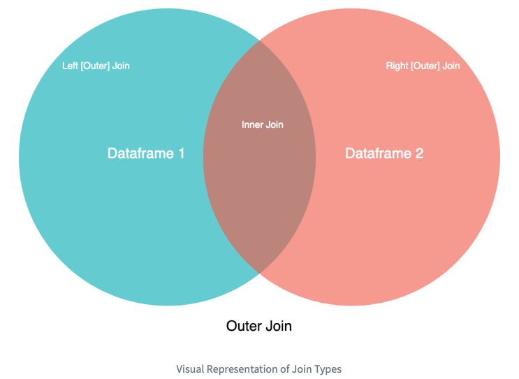

#### Ejemplo de tablas para aplicar combinaciones:

```python
df_user_table = pd.DataFrame(
    {
      'user_id' :[1,2,3,4,5],
      'like    ':['Paul','Ringo','John','George','Martin'],
    }
  )


df_languages = pd.DataFrame(
    {
      'user_id' :[3,1,1,5,4,6],
      'like    ':['C++','Python','R','Pascal','Java',"Lisp"],
    }
  )
print(df_user_table)
```

```
##    user_id like
## 0        1     Paul
## 1        2    Ringo
## 2        3     John
## 3        4   George
## 4        5   Martin
```

```python
print("++++++++++++++++++++]n")
```

```
## ++++++++++++++++++++]n
```

```python
print(df_languages)
```

```
##    user_id like
## 0        3      C++
## 1        1   Python
## 2        1        R
## 3        5   Pascal
## 4        4     Java
## 5        6     Lisp
```

```python
print("++++++++++++++++++++]n")
```

```
## ++++++++++++++++++++]n
```

### Intersección ( *inner* *join* )

```python
inner = pd.merge(df_user_table, df_languages, on='user_id', how='inner')
print(inner)
```

```
##    user_id like    _x like    _y
## 0        1       Paul     Python
## 1        1       Paul          R
## 2        3       John        C++
## 3        4     George       Java
## 4        5     Martin     Pascal
```

```python
print("++++++++++++++++++++]n")
```

```
## ++++++++++++++++++++]n
```

### *JOIN* por la izquierda

```python
left = pd.merge(df_user_table, df_languages, on='user_id', how='left')
print(left)
```

```
##    user_id like    _x like    _y
## 0        1       Paul     Python
## 1        1       Paul          R
## 2        2      Ringo        NaN
## 3        3       John        C++
## 4        4     George       Java
## 5        5     Martin     Pascal
```

```python
print("++++++++++++++++++++]n")
```

```
## ++++++++++++++++++++]n
```

### *JOIN* por la derecha

```python
right = pd.merge(df_user_table, df_languages, on='user_id', how='right')
print(right)
```

```
##    user_id like    _x like    _y
## 0        3       John        C++
## 1        1       Paul     Python
## 2        1       Paul          R
## 3        5     Martin     Pascal
## 4        4     George       Java
## 5        6        NaN       Lisp
```

```python
print("++++++++++++++++++++]n")
```

```
## ++++++++++++++++++++]n
```

### Union ( *outer* *join* )

```python
outer = pd.merge(df_user_table, df_languages, on='user_id', how='outer')
print(outer)
```

```
##    user_id like    _x like    _y
## 0        1       Paul     Python
## 1        1       Paul          R
## 2        2      Ringo        NaN
## 3        3       John        C++
## 4        4     George       Java
## 5        5     Martin     Pascal
## 6        6        NaN       Lisp
```

```python
print("++++++++++++++++++++]n")

#Repitiendo un ejemplo anterior con diferentes índices
```

```
## ++++++++++++++++++++]n
```

```python
df1 = pd.DataFrame({'A': ['A0', 'A1', 'A2', 'A3'],
                    'B': ['B0', 'B1', 'B2', 'B3'],
                    'C': ['C0', 'C1', 'C2', 'C3'],
                    'D': ['D0', 'D1', 'D2', 'D3']},
                    index=[0, 1, 2, 3])
print(df1)
```

```
##     A   B   C   D
## 0  A0  B0  C0  D0
## 1  A1  B1  C1  D1
## 2  A2  B2  C2  D2
## 3  A3  B3  C3  D3
```

```python
df2 = pd.DataFrame({'C': ['A4', 'A5', 'A6', 'A7'],
                    'D': ['B4', 'B5', 'B6', 'B7'],
                    'E': ['C4', 'C5', 'C6', 'C7'],
                    'F': ['D4', 'D5', 'D6', 'D7']},
                    index=[4, 5, 6, 7])
print(df2)
```

```
##     C   D   E   F
## 4  A4  B4  C4  D4
## 5  A5  B5  C5  D5
## 6  A6  B6  C6  D6
## 7  A7  B7  C7  D7
```

```python
resultado = pd.concat([df1, df2])
print(resultado)
```

```
##      A    B   C   D    E    F
## 0   A0   B0  C0  D0  NaN  NaN
## 1   A1   B1  C1  D1  NaN  NaN
## 2   A2   B2  C2  D2  NaN  NaN
## 3   A3   B3  C3  D3  NaN  NaN
## 4  NaN  NaN  A4  B4   C4   D4
## 5  NaN  NaN  A5  B5   C5   D5
## 6  NaN  NaN  A6  B6   C6   D6
## 7  NaN  NaN  A7  B7   C7   D7
```

```python
resultado = pd.concat([df1, df2],join='inner')
print(resultado)
```

```
##     C   D
## 0  C0  D0
## 1  C1  D1
## 2  C2  D2
## 3  C3  D3
## 4  A4  B4
## 5  A5  B5
## 6  A6  B6
## 7  A7  B7
```

```python
resultado = pd.concat([df1, df2],join='outer') # Por defecto es outer
print(resultado)
```

```
##      A    B   C   D    E    F
## 0   A0   B0  C0  D0  NaN  NaN
## 1   A1   B1  C1  D1  NaN  NaN
## 2   A2   B2  C2  D2  NaN  NaN
## 3   A3   B3  C3  D3  NaN  NaN
## 4  NaN  NaN  A4  B4   C4   D4
## 5  NaN  NaN  A5  B5   C5   D5
## 6  NaN  NaN  A6  B6   C6   D6
## 7  NaN  NaN  A7  B7   C7   D7
```

## Uso de Tablas Pivote.

Adicionalmente se pueden usar “tablas pivote” en *pandas*.

```python
# Tablas Pivote

titanic = sns.load_dataset('titanic')
titanic.shape
```

```
## (891, 15)
```

```python
titanic.head()
```

```
##    survived  pclass     sex   age  ...  deck  embark_town  alive  alone
## 0         0       3    male  22.0  ...   NaN  Southampton     no  False
## 1         1       1  female  38.0  ...     C    Cherbourg    yes  False
## 2         1       3  female  26.0  ...   NaN  Southampton    yes   True
## 3         1       1  female  35.0  ...     C  Southampton    yes  False
## 4         0       3    male  35.0  ...   NaN  Southampton     no   True
##
## [5 rows x 15 columns]
```

```python
titanic.groupby('sex')[['survived']].mean()
```

```
##         survived
## sex
## female  0.742038
## male    0.188908
```

```python
titanic.groupby(['sex', 'class'])['survived'].aggregate('mean')
```

```
## sex     class
## female  First     0.968085
##         Second    0.921053
##         Third     0.500000
## male    First     0.368852
##         Second    0.157407
##         Third     0.135447
## Name: survived, dtype: float64
```

```python
titanic.groupby(['sex', 'class'])['survived'].aggregate('mean').unstack()
```

```
## class      First    Second     Third
## sex
## female  0.968085  0.921053  0.500000
## male    0.368852  0.157407  0.135447
```

```python
titanic.groupby(['sex', 'class'])['survived'].aggregate('count').unstack() # Tabla cruzada



# Más fácil con una tabla pivote
```

```
## class   First  Second  Third
## sex
## female     94      76    144
## male      122     108    347
```

```python
titanic.pivot_table('survived', index='sex', columns='class')
```

```
## class      First    Second     Third
## sex
## female  0.968085  0.921053  0.500000
## male    0.368852  0.157407  0.135447
```

```python
titanic.pivot_table('survived', index='sex', columns='class',aggfunc='mean')
```

```
## class      First    Second     Third
## sex
## female  0.968085  0.921053  0.500000
## male    0.368852  0.157407  0.135447
```

```python
titanic.pivot_table('survived', index='sex', columns='class',aggfunc='count')
```

```
## class   First  Second  Third
## sex
## female     94      76    144
## male      122     108    347
```

```python
edad = pd.cut(titanic['age'], [0, 18, 80])
tabla_pivote=titanic.pivot_table('survived', ['sex', edad], 'class',aggfunc='count')

print(tabla_pivote)
```

```
## class            First  Second  Third
## sex    age
## female (0, 18]      11      14     43
##        (18, 80]     74      60     59
## male   (0, 18]       5      15     51
##        (18, 80]     96      84    202
```